# 01_exp_species-table

2023-07-06

- This code creates Supplemental Table I, which is a table of the mean densities (#/m3) of various zooplankton taxa stocked in each experiment. As a proxy for stocking density, I used data from tanks with zero jellies in them, excluding tanks that were sampled at the beginning of the experiment, as these tanks were not included in analyses down the line.
- This code also creates a stacked bar plot to visualize those data, which is not included in the paper.
- The RMarkdown file is here: https://rpubs.com/HailaSchultz/exp_species-table

load packages

```r
library(reshape2)
library(dplyr)
library(ggplot2)
library(forcats)
```

# Make tables

## subset database to experiment data zero-jelly tanks

Read database into R. If current database changes, just change the path

```r
Database <- read.csv("/Users/hailaschultz/Dropbox/Other studies/Aurelia project/Data Analysis/data/current_data/Final_Aurelia_Database_Jan11_2023.csv")
```

Subset to zero jelly tanks. First subset the trial type to Number, which codes for samples from experiments where the number of jellyfish in the tanks varies. Next, subset to all tanks with zero jellyfish added. This includes tanks sampled at the beginning of the experiment and tanks sampled at the end.

```r
Exp_data<-subset(Database,Trial.Type=="Number")
Exp_data_zerojellies<-subset(Exp_data,Number.of.Jellies=="0")
```

## remove tanks sampled at the beginning of the experiment

These tanks are removed because we decided not to include them in analyses down the line.

First, read in the file that designates different samples to tanks with jellies `other`, tanks with zero jellies sampled at the beginning of the experiment `remove`, and tanks with zero jellies sampled at the end of the experiment `zero`

```r
Control_tanks <- read.csv("/Users/hailaschultz/Dropbox/Other studies/Aurelia project/Data Analysis/data/current_data/Control_Tanks.csv")
```

Add control tank data to the database file

```r
Exp_data_zerojellies$Control_info <- Control_tanks$c1[match(Exp_data_zerojellies$Sample.Code, Control_tanks$Sample.Code)]
```

Remove tanks sampled at the beginning of the experiment

```r
Exp_data_control<-subset(Exp_data_zerojellies,Control_info!="remove")
```

## Combine taxa

Combine species and life history stage

```r
Exp_data_control$Species_lifestage <- paste(Exp_data_control$Genus.species, Exp_data_control$Life.History.Stage, sep="_")
```

```r
Exp_data_control <- Exp_data_control %>%
                   mutate(Species_lifestage_combined = fct_recode(Species_lifestage,
                                     "CALANOIDA_Medium" = "ACARTIA_Copepodite",
                                     "CALANOIDA_Medium" = "ACARTIA_Female, Adult",
                                     "CALANUS PACIFICUS" = "CALANUS PACIFICUS_C5-adult",
                                     "CALANUS PACIFICUS" = "CALANUS PACIFICUS_Female, Adult",
                                     "CALANUS PACIFICUS" = "CALANUS PACIFICUS_Male, Adult",
                                     "DITRICHOCORYCAEUS ANGLICUS" = "DITRICHOCORYCAEUS ANGLICUS_Large",
                                     "DITRICHOCORYCAEUS ANGLICUS" = "DITRICHOCORYCAEUS ANGLICUS_Small"))
```

Sum grouped taxa

```r
Exp_data_control_sum <-aggregate(Density....m3. ~ Sample.Code+Sample.Year+Sample.Date+Broad.Group+Species_lifestage_combined, data = Exp_data_control, sum)
```

## Calculate means and standard error per experiment

Summarize by experiment, taxon, and life history stage.

```r
Exp_data_control_sum <- Exp_data_control_sum %>%
  group_by(Sample.Year,Sample.Date,Broad.Group,Species_lifestage_combined) %>%
  summarise(
    mean = mean(Density....m3.),
    sd = sd(Density....m3.),
    n = n(),
    se = sd / sqrt(n)
  )
```

## Make mean and standard error tables

Mean table

```r
#reformat table
Exp_control_mean<-dcast(Exp_data_control_sum,Broad.Group+Species_lifestage_combined~Sample.Date, value.var = "mean")
```

Standard Error Table

```r
#reformat table
Exp_control_SE<-dcast(Exp_data_control_sum,Broad.Group+Species_lifestage_combined~Sample.Date, value.var = "se")
```

## Combine mean and standard error tables and format final table

```r
# Round dataframes to 2 decimal points
Exp_control_mean[, -c(1,2)]<-round(Exp_control_mean[, -c(1,2)],2)
Exp_control_SE[, -c(1,2)]<-round(Exp_control_SE[, -c(1,2)],2)
# Exclude first column
columns_to_combine <- names(Exp_control_mean)[-c(1,2)]

# Combine means and standard errors for selected columns
Exp_stock_densities <- data.frame(
  Exp_control_mean[, c(1,2)],
  sapply(columns_to_combine, function(col) {
   paste(Exp_control_mean[[col]], " ± ", Exp_control_SE[[col]])
  })
)
```

reformat species and date

```r
Exp_stock_densities$Species_lifestage_combined <- gsub("_", " ", Exp_stock_densities$Species_lifestage_combined)
```

reformat column names

```r
#remove X at the beginning
names(Exp_stock_densities)[3:ncol(Exp_stock_densities)] <- substring(names(Exp_stock_densities)[3:ncol(Exp_stock_densities)], 2)
#convert periods to slashes
colnames(Exp_stock_densities) <- sub("\\.", "/", colnames(Exp_stock_densities))
colnames(Exp_stock_densities) <- sub("\\.", "/", colnames(Exp_stock_densities))
#replace first column name
colnames(Exp_stock_densities)[colnames(Exp_stock_densities) == "xp_control_mean//.1."] <- "Taxa"
```

## Export table to csv

```r
write.csv(Exp_stock_densities,"/Users/hailaschultz/Dropbox/Other studies/Aurelia project/Data Analysis/output/Experiment_Stocking_Means.csv", row.names = FALSE)
```

From this point on, the table can be edited in excel to fit the correct format for the table

# Stacked Bar Chart

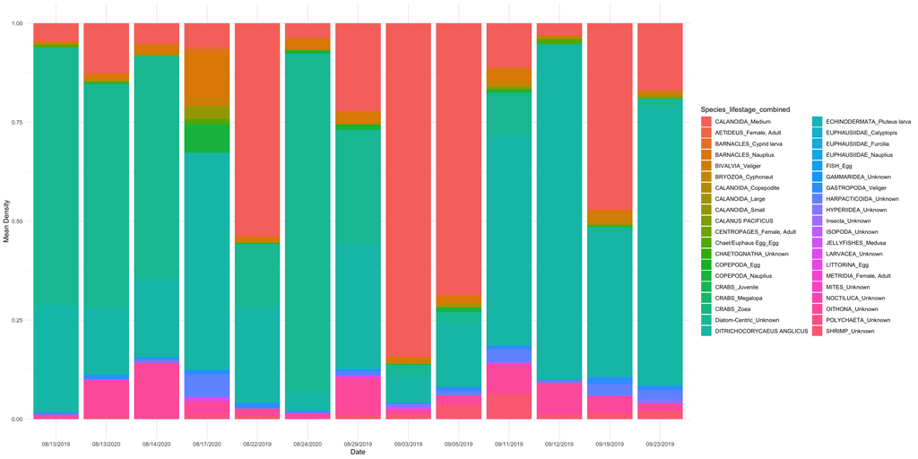

```r
Exp_stacked_barplot<-ggplot(Exp_data_control_sum, aes(x = Sample.Date, y = mean, fill = Species_lifestage_combined)) +
  geom_bar(stat = "identity",position = "fill") +
  labs(x = "Date", y = "Mean Density") +
  theme_minimal()
Exp_stacked_barplot
```

save plot as image

```r
setwd("/Users/hailaschultz/Dropbox/Other studies/Aurelia project/Data Analysis/output")
ggsave(plot = Exp_stacked_barplot, width = 20, height = 10, dpi = 300, filename = "Exp_stacked_barplot.png")
```